# Lab 3

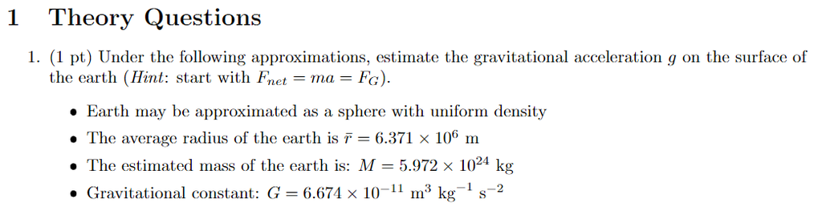

$$ F_{net} = F_G \\ mg = \frac{GMm}{r^2} \\ g = \frac{GM}{r^2} \\ = \frac{6.674e-11 \times 5.972e24}{(6.371e6)^2}\\ $$

```python
(6.674e-11)*(5.972e24)/((6.371e6)**2)
```

```
9.819532032815959
```

$$ =9.820 $$

Dimensional analysis: $$ [G][M][r^{-2}] \\ [m^3 kg^{-1} s^{-2}][kg][m^{-2}] = \frac{m}{s^2} $$ Looks good

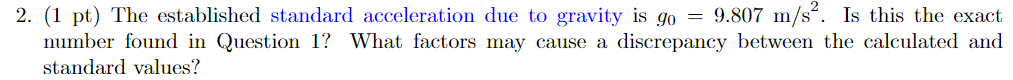

The formula assumes point masses, although the earth is more oval-shaped and may contribute gravitational force unevenly. The wikipedia page for this value explains:

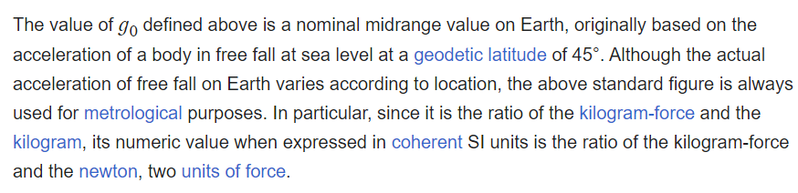

The radius $\bar r$ is not mentioned in the article, and it doesn't state how far that point is from the center of the earth.

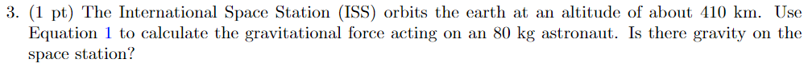

$$ r = \bar r + 410km $$ Convert units to add $$ 410km = 410000 r = 6371000 + 410000 = 6781000 = 6.8\times 10^6 $$ This gives us our force $$ F_G = \frac{GMm}{r^2} = 700N $$

```python
(6.674e-11)*(5.972e24)*(80)/((6.8e6)**2)
```

```
689.5696885813148
```

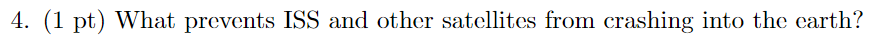

Centripedal motion. The force of gravity is necessary to maintain circular orbit around the earth. The satellites are moving so fast that they 'miss' the earth as they fall

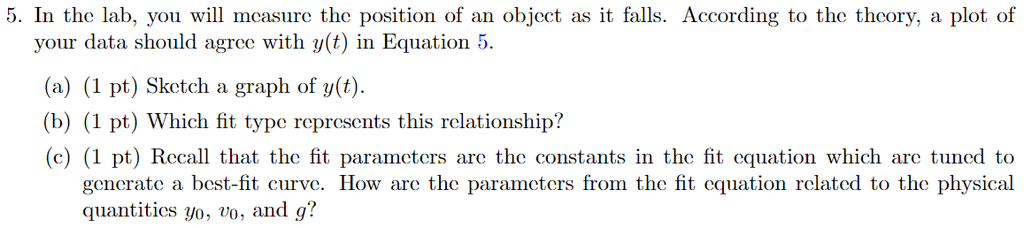

(a) see plot below

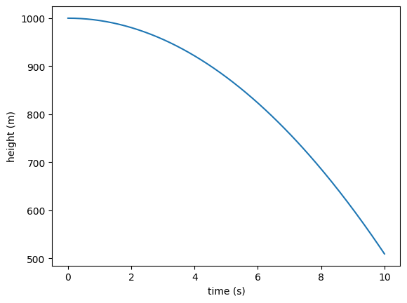

```python
import matplotlib.pyplot as plt
import numpy as np

tspan = np.linspace(0, 10, 200)

def y(t, g, v0, y0):
    return -g*t**2/2 + v0*t + y0

plt.plot(tspan, y(tspan, 9.81, 0, 1000))
plt.xlabel('time (s)')
plt.ylabel('height (m)');
```

(b) This is a polynomial fit

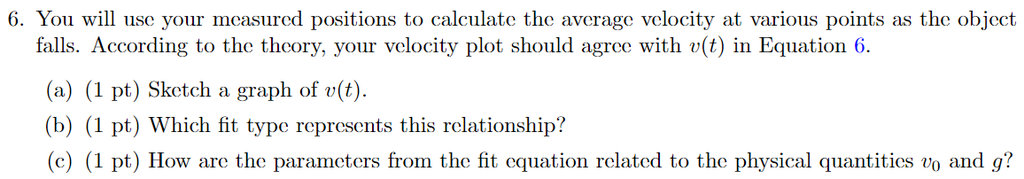

(a) see plot below

(b) linear

(c) g = a, v0 = b

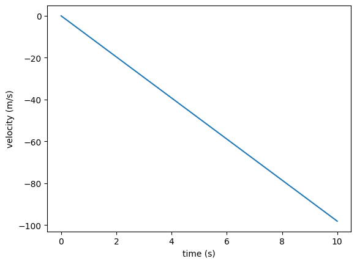

```python
def v(t, g, v0):
    return -g*t + v0*t

plt.plot(tspan, v(tspan, 9.81, 0))
plt.xlabel('time (s)')
plt.ylabel('velocity (m/s)');
```

Lab

```
32
4.528125
```

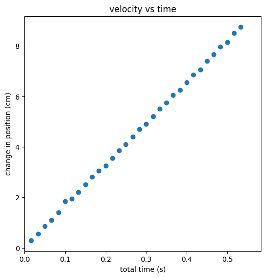

```python
import numpy as np
import matplotlib.pyplot as plt

cm_sep = np.array([
    0.30, 0.55, 0.85, 1.10, 1.40,
    1.85, 1.95, 2.20, 2.50, 2.80,
    3.05, 3.25, 3.55, 3.85, 4.10,
    4.40, 4.70, 4.90, 5.20, 5.50,
    5.75, 6.05, 6.25, 6.55, 6.85,
    7.05, 7.40, 7.65, 7.95, 8.15,
    8.50, 8.75
])

dt = 1/60
time_sep = np.arange(1, len(cm_sep)+1)*1/60

print(len(cm_sep))
print(cm_sep.mean())

plt.figure(figsize=(6,6))
plt.scatter(time_sep, cm_sep)
plt.xlim(0, 35*dt)
plt.xlabel('total time (s)')
plt.ylabel('change in position (cm)')
plt.title('velocity vs time')
```

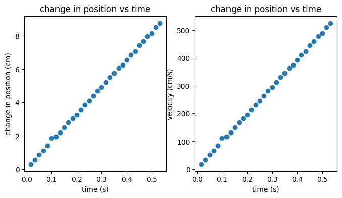

```python
fig, (ax1, ax2) = plt.subplots(1, 2, figsize=(8,4), sharex=True)

ax1.scatter(time_sep, cm_sep)
ax1.set_xlabel('time (s)')
ax1.set_ylabel('change in position (cm)')
ax1.set_title('change in position vs time')

ax2.scatter(time_sep, cm_sep/dt)
ax2.set_xlabel('time (s)')
ax2.set_ylabel('velocity (cm/s)')
ax2.set_title('change in position vs time')
```

## Part 3: Velocity Model

1. We will show the error of each approach.

Method A: Error propogation is not necessary this is simply the error of the measurement device, which for a meter stick is 0.05 cm

Method B: Error comes from two measurements $\Delta y_i = y_i - y_{i-1}$. The partial derivatives with respect to each measurement are $1$ and $-1$, so the resulting error is

$$ \delta \Delta y_i = \sqrt{\left(\delta y_i \right)^2+\left(\delta y_{i-1} \right)^2} = 0.05\sqrt{2} = 0.07 \text{cm} $$

Since our data (collected in Part 2: Position model) recorded measurements using Method A, this is what we will report with. This turned out to have a smaller error than Method B anyways.

2. For this part of the experiment, we will approximate gravitational acceleration $g$ using the linear equation for freefall with zero initial velocity $v(t) = gt$ and construct error bars on the actual value
3. The formula for velocity from distance over time is $v = \frac{\Delta y}{\Delta t}$ Since relative uncertainty in time is negligible, our error propogation formula reduces to

$$ \delta v = \left|\frac{\partial v}{\partial \Delta y} \delta \Delta y\right| = \frac{1}{\Delta t} \delta \Delta y = 60*0.05 = 3 \text{cm/s} $$

4. The formula is linear $v(t) = gt + v_0$, where $g$ is gravitational accceleration and $v_0=0$
5. See dataframe below

```python
import numpy as np
import pandas as pd

Dt = 1/60

cm_sep = np.array([
    0.30, 0.55, 0.85, 1.10, 1.40,
    1.85, 1.95, 2.20, 2.50, 2.80,
    3.05, 3.25, 3.55, 3.85, 4.10,
    4.40, 4.70, 4.90, 5.20, 5.50,
    5.75, 6.05, 6.25, 6.55, 6.85,
    7.05, 7.40, 7.65, 7.95, 8.15,
    8.50, 8.75
])

ti = np.array([(i+1)*Dt for i in range(len(cm_sep))])
ti = np.trunc(ti*1000)/1000

table = pd.DataFrame({
    'ti (s)': ti,
    'Dyi (cm)': cm_sep
})

table['v_avg (cm/s)'] = table['Dyi (cm)'] / dt

table['Dyi error (cm)'] = 0.05
table['v_avg error (cm/s)'] = table['Dyi error (cm)'] / Dt

#table.to_csv('the_text.csv')
table
```

|  | ti (s) | Dyi (cm) | v_avg (cm/s) | Dyi error (cm) | v_avg error (cm/s) |
| --- | --- | --- | --- | --- | --- |
| 0 | 0.016 | 0.30 | 18.0 | 0.05 | 3.0 |
| 1 | 0.033 | 0.55 | 33.0 | 0.05 | 3.0 |
| 2 | 0.050 | 0.85 | 51.0 | 0.05 | 3.0 |
| 3 | 0.066 | 1.10 | 66.0 | 0.05 | 3.0 |
| 4 | 0.083 | 1.40 | 84.0 | 0.05 | 3.0 |
| 5 | 0.100 | 1.85 | 111.0 | 0.05 | 3.0 |
| 6 | 0.116 | 1.95 | 117.0 | 0.05 | 3.0 |
| 7 | 0.133 | 2.20 | 132.0 | 0.05 | 3.0 |
| 8 | 0.150 | 2.50 | 150.0 | 0.05 | 3.0 |
| 9 | 0.166 | 2.80 | 168.0 | 0.05 | 3.0 |
| 10 | 0.183 | 3.05 | 183.0 | 0.05 | 3.0 |
| 11 | 0.200 | 3.25 | 195.0 | 0.05 | 3.0 |
| 12 | 0.216 | 3.55 | 213.0 | 0.05 | 3.0 |
| 13 | 0.233 | 3.85 | 231.0 | 0.05 | 3.0 |
| 14 | 0.250 | 4.10 | 246.0 | 0.05 | 3.0 |
| 15 | 0.266 | 4.40 | 264.0 | 0.05 | 3.0 |
| 16 | 0.283 | 4.70 | 282.0 | 0.05 | 3.0 |
| 17 | 0.300 | 4.90 | 294.0 | 0.05 | 3.0 |
| 18 | 0.316 | 5.20 | 312.0 | 0.05 | 3.0 |
| 19 | 0.333 | 5.50 | 330.0 | 0.05 | 3.0 |
| 20 | 0.350 | 5.75 | 345.0 | 0.05 | 3.0 |
| 21 | 0.366 | 6.05 | 363.0 | 0.05 | 3.0 |
| 22 | 0.383 | 6.25 | 375.0 | 0.05 | 3.0 |
| 23 | 0.400 | 6.55 | 393.0 | 0.05 | 3.0 |
| 24 | 0.416 | 6.85 | 411.0 | 0.05 | 3.0 |
| 25 | 0.433 | 7.05 | 423.0 | 0.05 | 3.0 |
| 26 | 0.450 | 7.40 | 444.0 | 0.05 | 3.0 |
| 27 | 0.466 | 7.65 | 459.0 | 0.05 | 3.0 |
| 28 | 0.483 | 7.95 | 477.0 | 0.05 | 3.0 |
| 29 | 0.500 | 8.15 | 489.0 | 0.05 | 3.0 |
| 30 | 0.516 | 8.50 | 510.0 | 0.05 | 3.0 |
| 31 | 0.533 | 8.75 | 525.0 | 0.05 | 3.0 |

6. See plot below

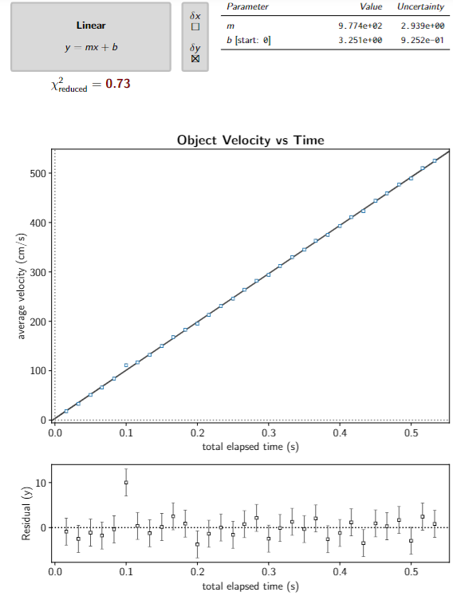

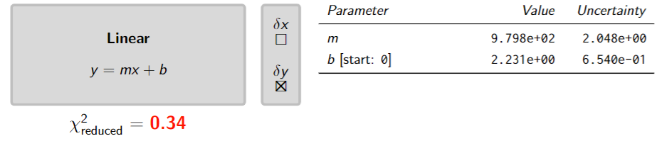

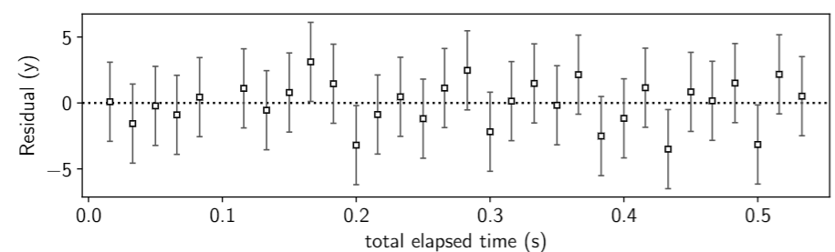

Some data point's error bars fall short of the line, but remember that standard error is not an absolute bound on the actual value and error can come from various sources.